# Patterns for Regression Models

## Fifth Simulation

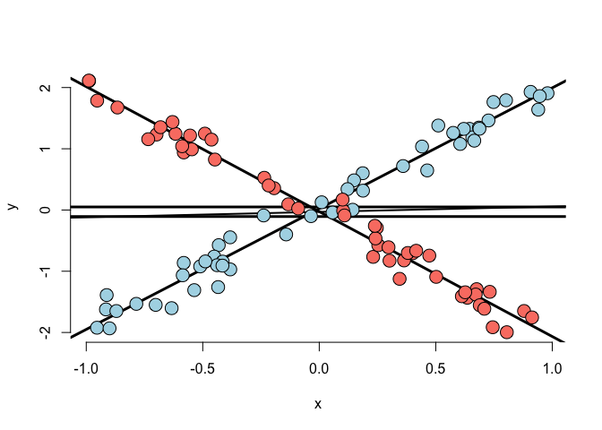

```r
n <- 100; t <- rep(c(0, 1), c(n/2, n/2)); x <- c(runif(n/2, -1, 1), runif(n/2, -1, 1));
beta0 <- 0; beta1 <- 2; tau <- 0; tau1 <- -4; sigma <- .2
y <- beta0 + x * beta1 + t * tau + t * x * tau1 + rnorm(n, sd = sigma)
plot(x, y, type = "n", frame = FALSE)
abline(lm(y ~ x), lwd = 2)
abline(h = mean(y[1 : (n/2)]), lwd = 3)
abline(h = mean(y[(n/2 + 1) : n]), lwd = 3)
fit <- lm(y ~ x + t + I(x * t))
abline(coef(fit)[1], coef(fit)[2], lwd = 3)
abline(coef(fit)[1] + coef(fit)[3], coef(fit)[2] + coef(fit)[4], lwd = 3)
points(x[1 : (n/2)], y[1 : (n/2)], pch = 21, col = "black", bg = "lightblue", cex = 2)
points(x[(n/2 + 1) : n], y[(n/2 + 1) : n], pch = 21, col = "black", bg = "salmon", cex = 2)
```

## Sixth Simulation

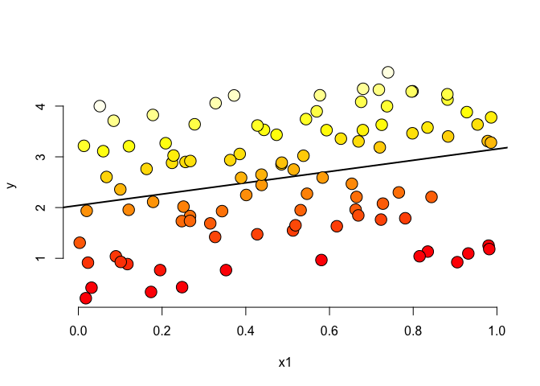

```r
p <- 1
n <- 100; x2 <- runif(n); x1 <- p * runif(n) - (1 - p) * x2
beta0 <- 0; beta1 <- 1; tau <- 4 ; sigma <- .01
y <- beta0 + x1 * beta1 + tau * x2 + rnorm(n, sd = sigma)
plot(x1, y, type = "n", frame = FALSE)
abline(lm(y ~ x1), lwd = 2)
co.pal <- heat.colors(n)
points(x1, y, pch = 21, col = "black", bg = co.pal[round((n - 1) * x2 + 1)], cex = 2)
```

Bivariate Relationships, for use in a X11 enabled display:

```r
library(rgl)
plot3d(x1, x2, y)
```

Residual Relationships

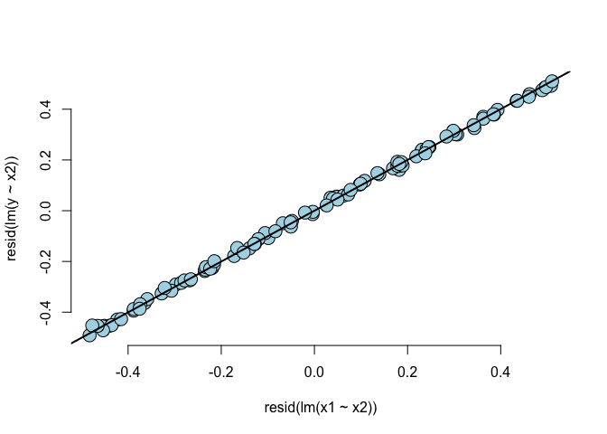

```r
plot(resid(lm(x1 ~ x2)), resid(lm(y ~ x2)), frame = FALSE, col = "black", bg = "lightblue", pch = 21, cex = 2)
abline(lm(I(resid(lm(x1 ~ x2))) ~ I(resid(lm(y ~ x2)))), lwd = 2)
```

- X1 unrelated to X2
- X2 strongly related to Y
- Adjusted relationship between X1 and Y largely unchanged by considering X2.
  - Almost no residual variability after accounting for X2.

# Residuals and Diagnostics

## Plot of features of a fit

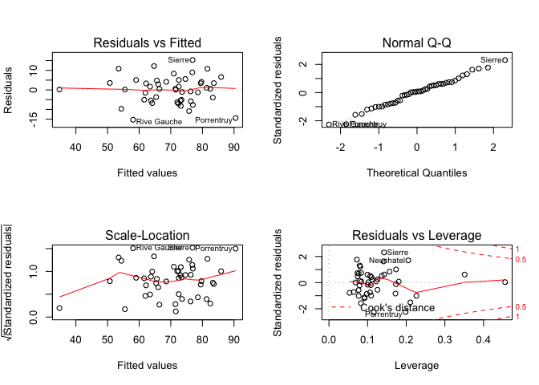

```r
data(swiss);
par(mfrow=c(2,2))
fit <- lm(Fertility ~ ., data=swiss)
plot(fit)
```

## Influence, Leverage and Outliers

- Leverage: how far away is the data point from the center of mass of a distribution
- Influence: An observation is influential if an estimate changes substantially after that data point is removed

So, give the following points:

```r
x <- c(0.586, 0.166, -0.042, -0.614, 11.72)
y <- c(0.549, -0.026, -0.127, -0.751, 1.344)
fit <- lm(y ~ x)
```

What is the hat-value (measures of leverage) of the most influencial point?

```r
max(hatvalues(fit))
```

```
## [1] 0.9945734
```

What the slope dfbeta for the point with the highest hat-value?

```r
influence.measures(fit)$infmat
```

```
##        dfb.1_         dfb.x         dffit     cov.r       cook.d       hat
## 1  1.06212391   -0.37811633    1.06794603 0.3412772 2.925794e-01 0.2286650
## 2  0.06748037   -0.02861769    0.06750799 2.9338458 3.394011e-03 0.2438146
## 3 -0.01735756    0.00791512   -0.01735800 3.0073613 2.258743e-04 0.2525027
## 4 -1.24958248    0.67253246   -1.25570867 0.3422019 3.912201e-01 0.2804443
## 5  0.20432010 -133.82261293 -149.72037760 0.1073304 2.704935e+02 0.9945734
```

We look for the column `dfb.x` for the highest `hat` value (**0.9945734**) - so the value is **-133.82261293**

### Case 1

Several data points, one is clearly an outlier (first point, (10,10))

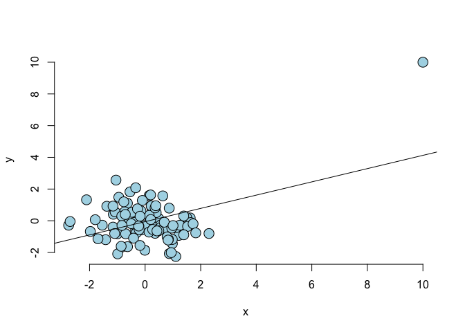

```r
x <- c(10, rnorm(n)); y <- c(10, c(rnorm(n)))
plot(x, y, frame = FALSE, cex = 2, pch = 21, bg = "lightblue", col = "black")
abline(lm(y ~ x))
```

How can we measure that? First, using `dfbetas`: change in individual coefficients when the $i^{th}$ point is deleted in fitting the model.

```r
fit <- lm(y ~ x)
round(dfbetas(fit)[1:10, 2], 3)
```

```
##      1      2      3      4      5      6      7      8      9     10
##  8.817 -0.090  0.064 -0.285 -0.072  0.009  0.020 -0.004  0.008 -0.051
```

Measurement of the first point is orders of magnitude higher than other points.

Second, using `hatvalue`: measures of leverage

```r
round(hatvalues(fit)[1:10], 3)
```

```
##     1     2     3     4     5     6     7     8     9    10
## 0.509 0.017 0.014 0.033 0.012 0.011 0.015 0.011 0.010 0.011
```

Measurement of the first point is higher than other points.

### Case 2

Several data points, one is clearly an outlier but laying on top of the regression line

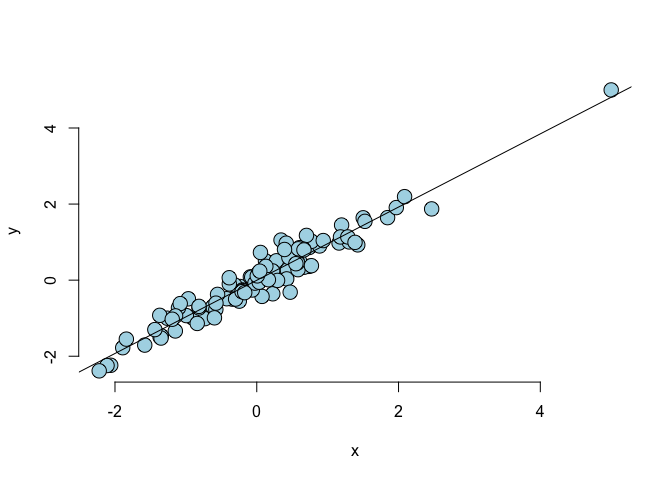

```r
x <- rnorm(n); y <- x + rnorm(n, sd = .3)
x <- c(5, x); y <- c(5, y)
plot(x, y, frame = FALSE, cex = 2, pch = 21, bg = "lightblue", col = "black")
fit2 <- lm(y ~ x)
abline(fit2)
```

```r
round(dfbetas(fit2)[1 : 10, 2], 3)
```

```
##      1      2      3      4      5      6      7      8      9     10
##  0.402  0.045  0.037 -0.051 -0.079  0.000  0.035  0.097 -0.153 -0.006
```

Still large, but not as much as others

```r
round(hatvalues(fit2)[1 : 10], 3)
```

```
##     1     2     3     4     5     6     7     8     9    10
## 0.217 0.013 0.018 0.020 0.037 0.011 0.014 0.028 0.019 0.011
```

### Stefanski Example

Download sample file, cached:

```r
dat <- read.table('http://www4.stat.ncsu.edu/~stefanski/NSF_Supported/Hidden_Images/orly_owl_files/orly_owl_Lin_4p_5_flat.txt', header = FALSE)
```

Pairs plot, quick glimpse.

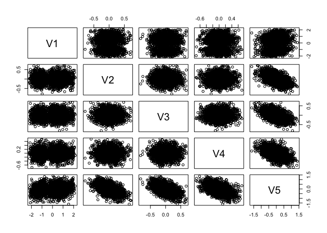

```r
pairs(dat)
```

Not much, a lot of overplotting clouds over the 5 features.

Let’s fit a liner model on all 5 features:

```r
summary(lm(V1 ~ . -1, data=dat))$coef
```

```
##     Estimate Std. Error   t value     Pr(>|t|)
## V2 0.9856157 0.12798121  7.701253 1.989126e-14
## V3 0.9714707 0.12663829  7.671225 2.500259e-14
## V4 0.8606368 0.11958267  7.197003 8.301184e-13
## V5 0.9266981 0.08328434 11.126919 4.778110e-28
```

Let’s plot the residuals against predictions, $\hat Y_i$ in $x$ and residuals $e_i$ in $y$:

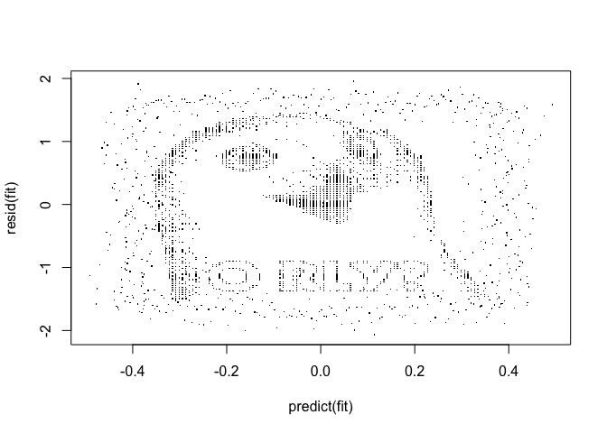

```r
fit <- lm(V1 ~ . -1, data=dat)
plot(predict(fit), resid(fit), pch='.')
```

# Model Selection

Answering the question: How do we chose what variables to include in a regression model?

## Simulating Impact of New Regressors in $R^2$

Also known as variance inflation.

Here is a simulation of adding a number of uncorrelated regressors:

```r
n <- 100; nosim <- 1000
x1 <- rnorm(n); x2 <- rnorm(n); x3 <- rnorm(n);
betas <- sapply(1 : nosim, function(i){
  y <- x1 + rnorm(n, sd = .3)
  c(coef(lm(y ~ x1))[2],
    coef(lm(y ~ x1 + x2))[2],
    coef(lm(y ~ x1 + x2 + x3))[2])
})
round(apply(betas, 1, sd), 5)
```

```
##      x1      x1      x1
## 0.03140 0.03141 0.03260
```

You can see that standard deviation did not change by a large number.

Now, let’s simulate highly correlated regressors:

```r
n <- 100; nosim <- 1000
x1 <- rnorm(n); x2 <- x1/sqrt(2) + rnorm(n) /sqrt(2)
x3 <- x1 * 0.95 + rnorm(n) * sqrt(1 - 0.95^2);
betas <- sapply(1 : nosim, function(i){
  y <- x1 + rnorm(n, sd = .3)
  c(coef(lm(y ~ x1))[2],
    coef(lm(y ~ x1 + x2))[2],
    coef(lm(y ~ x1 + x2 + x3))[2])
})
round(apply(betas, 1, sd), 5)
```

```
##      x1      x1      x1
## 0.02813 0.04460 0.10029
```

In this case the standard deviation increased by a lot.

On other words: **if we omit regressors we get biased, if we include unnecessary regressors we increase the standards error.**

### Variance Inflation Factor (VIF)

```r
data(swiss)
fit <- lm(Fertility ~ . , data = swiss)
fit1 <- lm(Fertility ~ Agriculture, data = swiss)
a <- summary(fit1)$cov.unscaled[2,2]
fit2 <- update(fit, Fertility ~ Agriculture + Examination)
fit3 <- update(fit, Fertility ~ Agriculture + Examination + Education)
  c(summary(fit2)$cov.unscaled[2,2],
    summary(fit3)$cov.unscaled[2,2]) / a
```

```
## [1] 1.891576 2.089159
```

```r
library(car)
fit <- lm(Fertility ~ . , data = swiss)
vif(fit)
```

```
##      Agriculture      Examination        Education         Catholic
##         2.284129         3.675420         2.774943         1.937160
## Infant.Mortality
##         1.107542
```

Means that agriculture for example has 2 times impact in error in comparison if it was a purely random regressor. Infant.Mortality (low, approx 1) is uncorrelated to any of the other regressors.

```r
sqrt(vif(fit)) #I prefer sd
```

```
##      Agriculture      Examination        Education         Catholic
##         1.511334         1.917138         1.665816         1.391819
## Infant.Mortality
##         1.052398
```

### Nested Models

As example of a nested models, let’s fit three nested models, adding new regressors on each model: fertility and agriculture first, and on subsequent step fit examination and education, and in a last step catholic and infant mortality.

```r
fit1 <- lm(Fertility ~ Agriculture, data = swiss)
fit3 <- update(fit, Fertility ~ Agriculture + Examination + Education)
fit5 <- update(fit, Fertility ~ Agriculture + Examination + Education + Catholic + Infant.Mortality)
anova(fit1, fit3, fit5)
```

```
## Analysis of Variance Table
##
## Model 1: Fertility ~ Agriculture
## Model 2: Fertility ~ Agriculture + Examination + Education
## Model 3: Fertility ~ Agriculture + Examination + Education + Catholic +
##     Infant.Mortality
##   Res.Df    RSS Df Sum of Sq      F    Pr(>F)
## 1     45 6283.1
## 2     43 3180.9  2    3102.2 30.211 8.638e-09 ***
## 3     41 2105.0  2    1075.9 10.477 0.0002111 ***
## ---
## Signif. codes:  0 '***' 0.001 '**' 0.01 '*' 0.05 '.' 0.1 ' ' 1
```

This gives a list of the three models and a number of columns. The F statistic tests the predictive capability of the model as a whole - the larger the F value the better your model is at predicting the dependent variable. Lower F values indicate the model is not as good at predicting the dependent variable.